# (PSL) Clustering

```python
import warnings
warnings.filterwarnings('ignore')

import seaborn as sns
import matplotlib.cm as cm
import matplotlib.pyplot as plt
import pandas as pd
import numpy as np

from sklearn.metrics import pairwise_distances, confusion_matrix
from sklearn.metrics import silhouette_score, silhouette_samples
from sklearn.cluster import KMeans

from scipy.cluster.hierarchy import linkage, dendrogram
from sklearn_extra.cluster import KMedoids
```

```python
# ref: https://pyseer.readthedocs.io/en/master/_modules/pyseer/cmdscale.html
def cmdscale(D):
    """Classical multidimensional scaling (MDS)

    Args:
        D (numpy.array)
            Symmetric distance matrix (n, n)

    Returns:
        Y (numpy.array)
            Configuration matrix (n, p). Each column represents a dimension. Only the
            p dimensions corresponding to positive eigenvalues of B are returned.
            Note that each dimension is only determined up to an overall sign,
            corresponding to a reflection.
        e (numpy.array)
            Eigenvalues of B (n, 1)
    """
    # Number of points
    n = len(D)

    # Centering matrix
    H = np.eye(n) - np.ones((n, n))/n

    # YY^T
    B = -H.dot(D**2).dot(H)/2

    # Diagonalize
    evals, evecs = np.linalg.eigh(B)

    # Sort by eigenvalue in descending order
    idx = np.argsort(evals)[::-1]
    evals = evals[idx]
    evecs = evecs[:, idx]

    # Compute the coordinates using positive-eigenvalued components only
    w, = np.where(evals > 0)
    L = np.diag(np.sqrt(evals[w]))
    V = evecs[:, w]
    Y = V.dot(L)

    return Y
```

```python
# Source: https://scikit-learn.org/stable/auto_examples/cluster/plot_kmeans_silhouette_analysis.html
def silhouette_plot(kmeans, data, ax):
    n_clusters = kmeans.n_clusters
    cluster_labels = kmeans.labels_
    silhouette_avg = silhouette_score(data, cluster_labels)
    sample_silhouette_values = silhouette_samples(data, cluster_labels)

    y_lower = 10
    for i in range(n_clusters):
        # Aggregate the silhouette scores for samples belonging to
        # cluster i, and sort them
        ith_cluster_silhouette_values = sample_silhouette_values[cluster_labels == i]

        ith_cluster_silhouette_values.sort()

        size_cluster_i = ith_cluster_silhouette_values.shape[0]
        y_upper = y_lower + size_cluster_i

        color = cm.nipy_spectral(float(i) / n_clusters)
        ax.fill_betweenx(
            np.arange(y_lower, y_upper),
            0,
            ith_cluster_silhouette_values,
            facecolor=color,
            edgecolor=color,
            alpha=0.7,
        )

        # Label the silhouette plots with their cluster numbers at the middle
        ax.text(-0.05, y_lower + 0.5 * size_cluster_i, str(i))

        # Compute the new y_lower for next plot
        y_lower = y_upper + 10  # 10 for the 0 samples

    ax.set_title("Silhouette plot of $K=%i$ clusters." % n_clusters)
    ax.set_xlabel("Silhouette Width")
    ax.set_ylabel("Cluster Label")

    # The vertical line for average silhouette score of all the values
    ax.axvline(x=silhouette_avg, color="red", linestyle="--")

    ax.set_yticks([])  # Clear the yaxis labels / ticks
    ax.set_xticks([-0.1, 0, 0.2, 0.4, 0.6, 0.8, 1])
```

## Multidimensional Scaling

To elucidate the concept of multidimensional scaling, let's consider a dataset from a study that aimed to determine which pairs of letters people frequently confuse.

The table below is from Wolford and Hollingsworth (1974). The set comprises eight letters: C, D, G, H, M, N, Q, and W. This results in an 8×8 matrix. Each cell in this matrix indicates the frequency with which people confuse the corresponding row and column letters.

```python
D = np.zeros((8, 8))
D[1:8, 0] = [5, 12, 2, 2, 2, 9, 1]
D[2:8, 1] = [2, 4, 3, 4, 20, 5]
D[3:8, 2] = [3, 2, 1, 9, 2]
D[4:8, 3] = [19, 18, 1, 5]
D[5:8, 4] = [16, 2, 18]
D[6:8, 5] = [8, 13]
D[7, 6] = 4
D = D + D.T

letters = ["C", "D", "G", "H", "M", "N", "Q", "W"]
D = pd.DataFrame(D, columns=letters, index=letters)
D
```

|  | C | D | G | H | M | N | Q | W |
| --- | --- | --- | --- | --- | --- | --- | --- | --- |
| C | 0.0 | 5.0 | 12.0 | 2.0 | 2.0 | 2.0 | 9.0 | 1.0 |
| D | 5.0 | 0.0 | 2.0 | 4.0 | 3.0 | 4.0 | 20.0 | 5.0 |
| G | 12.0 | 2.0 | 0.0 | 3.0 | 2.0 | 1.0 | 9.0 | 2.0 |
| H | 2.0 | 4.0 | 3.0 | 0.0 | 19.0 | 18.0 | 1.0 | 5.0 |
| M | 2.0 | 3.0 | 2.0 | 19.0 | 0.0 | 16.0 | 2.0 | 18.0 |
| N | 2.0 | 4.0 | 1.0 | 18.0 | 16.0 | 0.0 | 8.0 | 13.0 |
| Q | 9.0 | 20.0 | 9.0 | 1.0 | 2.0 | 8.0 | 0.0 | 4.0 |
| W | 1.0 | 5.0 | 2.0 | 5.0 | 18.0 | 13.0 | 4.0 | 0.0 |

The matrix $\mathbf{D}$ is symmetric and represents similarity, not distance. A higher value signifies that the two letters (row and column) are easily confused, indicating their similarity.

First, we change the similarity matrix $\mathbf{D}$ to a distance matrix $\mathbf{D}_0$ using the formula $21-\mathbf{D}$. This essentially inverts the sign, ensuring all entries remain positive (given the highest value in $\mathbf{D}$ is 20). The resultant matrix, $\mathbf{D}_0$, serves as our distance matrix. We also set the diagonal of $\mathbf{D}_0$ to zero since the distance between identical letters should always be zero.

```python
D0 = 21 - D
np.fill_diagonal(D0.values, 0)
```

Applying multidimensional scaling to this matrix and by default embedding the data in a two-dimensional space, we get a visual representation. An alternative transformation for the similarity-to-distance matrix conversion, using $41-\mathbf{D}$, was also tried. The results were largely consistent, albeit with slight variations in scale.

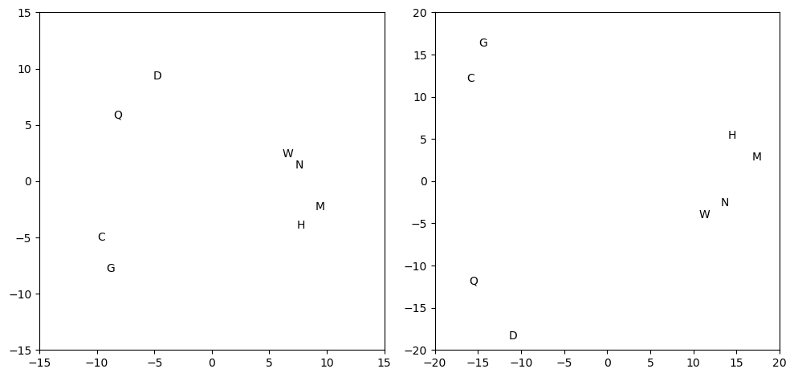

```python
tmp = cmdscale(D0)

fig, axes = plt.subplots(nrows=1, ncols=2)
axes[0].plot(tmp[:, 0], tmp[:, 1], 'none', markersize=5)
axes[0].set_xlim(-15, 15)
axes[0].set_ylim(-15, 15)
for i, txt in enumerate(letters):
    axes[0].annotate(txt, (tmp[i, 0], tmp[i, 1]), ha='center', va='center')

D1 = 41 - D
np.fill_diagonal(D1.values, 0)
tmp = cmdscale(D1)
axes[1].plot(tmp[:, 0], tmp[:, 1], 'none', markersize=5)
axes[1].set_xlim(-20, 20)
axes[1].set_ylim(-20, 20)
for i, txt in enumerate(letters):
    axes[1].annotate(txt, (tmp[i, 0], tmp[i, 1]), ha='center', va='center')

fig.set_figwidth(10)
fig.tight_layout()
```

From the visual representation, it becomes evident that the letters D and Q are similar, as are C and G. Additionally, a cluster of four other letters seems to share certain similarities.

## K-means

```python
url = "https://raw.githubusercontent.com/liangfgithub/liangfgithub.github.io/master/Data/sportsranks.csv"
sportsranks = pd.read_csv(url)
sportsranks.head()
```

|  | Baseball | Football | Basketball | Tennis | Cycling | Swimming | Jogging |
| --- | --- | --- | --- | --- | --- | --- | --- |
| 0 | 1 | 3 | 7 | 2 | 4 | 5 | 6 |
| 1 | 1 | 3 | 2 | 5 | 4 | 7 | 6 |
| 2 | 1 | 3 | 2 | 5 | 4 | 7 | 6 |
| 3 | 4 | 7 | 3 | 1 | 5 | 6 | 2 |
| 4 | 2 | 3 | 1 | 7 | 6 | 5 | 4 |

To analyze this data, we employed the K-means clustering method with K set to 2 and 3.

```python
km2 = KMeans(n_clusters=2, n_init=10).fit(sportsranks)
km3 = KMeans(n_clusters=3, n_init=10).fit(sportsranks)
```

To visualize the results, we utilized a multidimensional scaling (MDS) representation, plotted in a two-dimensional space. This MDS was calculated using the `cmdscale` function defined above.

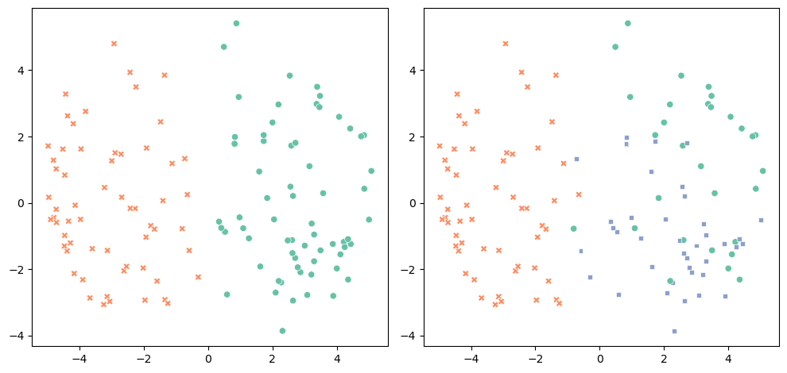

```python
D = pairwise_distances(sportsranks)
Xmds = cmdscale(D)

fig, axes = plt.subplots(nrows=1, ncols=2)
sns.scatterplot(x=Xmds[:, 0], y=Xmds[:, 1], hue=km2.labels_,
                style=km2.labels_, palette="Set2", legend=False, ax=axes[0])
sns.scatterplot(x=Xmds[:, 0], y=Xmds[:, 1], hue=km3.labels_,
                style=km3.labels_, palette="Set2", legend=False, ax=axes[1])
fig.set_figwidth(10)
fig.tight_layout()
```

Moreover, we manually computed the MDS by first applying double-centering, followed by singular value decomposition. We extracted the first two columns, essentially representing the two-dimensional space. A correlation check between our computed two-dimensional MDS and that returned by the `cmdscale` function revealed that they were virtually identical.

```python
D2 = D ** 2
n = D2.shape[0]
D2_mean = D2.mean()
D2_colMean = np.broadcast_to(np.mean(D2, axis=0), (n, n))
D2_rowMean = D2_colMean.T

tmp = D2 - D2_colMean - D2_rowMean
tmp = -(tmp + D2_mean) / 2
tmp_svd = np.linalg.svd(tmp)
F = tmp_svd[0][:, 0:2] @ np.diag(tmp_svd[1][0:2] ** 0.5)

# check the correlations
print(np.corrcoef(F[:, 0], Xmds[:, 0])[0, 1])
print(np.corrcoef(F[:, 0], Xmds[:, 1])[0, 1])
print(np.corrcoef(F[:, 1], Xmds[:, 0])[0, 1])
print(np.corrcoef(F[:, 1], Xmds[:, 1])[0, 1])
```

```
1.0
-1.5331171381692608e-16
4.3823592026289615e-17
-0.9999999999999993
```

The plots indicate that setting K to 2 might be sufficient since using K = 3 began to display overlapping clusters. To verify our choice of K, we employed the gap statistic method.

## Gap Statistics

We will compute the gap statistic step by step.

- Step 1: Calculate Within-Cluster-SS. For various K values, we compute the Within-Cluster-SS for the observed data using K-means. This involved specifying K as the number of clusters and instructing Python to run ten randomized initializations `n_init = 10`, selecting the one yielding the smallest sum.

```python
n = 130
ss = []
ss.append(np.sum(np.var(sportsranks, ddof=1)) * (n - 1))

for i in range(2, 11):
    km_temp = KMeans(n_clusters=i, n_init=10).fit(sportsranks)
    ss.append(km_temp.inertia_)

lss = np.log(ss)
```

- Step 2: Calculate SS_0(K) under Reference Distribution. For our data, the reference distribution was generated by creating samples where each entry was a random permutation of the numbers 1 through 7. This approach ensured that our reference data was devoid of any inherent clustering structure. We created 50 sets of this data and computed the Within-Cluster-SS for each set.

```python
m = 7  # each review is a permutation of numbers from 1 to 7
B = 50  # number of iterations
lss0 = np.zeros((B, 10))

for i in range(B):
    xstar = np.array(
        [np.random.choice(range(m), size=m, replace=False) for i in range(n)])
    lss0[i, 0] = np.log(np.sum(np.var(xstar, axis=0, ddof=1)) * (n - 1))
    for j in range(1, 11):
        km_temp = KMeans(n_clusters=j, n_init=10).fit(xstar)
        lss0[i, j - 1] = np.log(km_temp.inertia_)
```

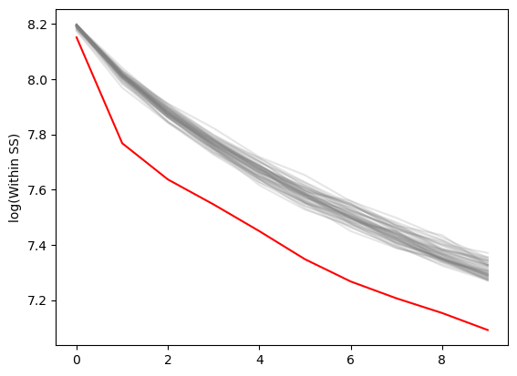

```python
plt.plot(lss0.T, color='gray', alpha=0.2)
plt.plot(lss, color='red')
plt.ylabel('log(Within SS)')
plt.show()
```

Plot the Gap curve. Based on the 1se rule, the most considerable gap difference appeared at K=2. Thus, we concluded that K=2 is the optimal choice based on the gap statistic, confirming our earlier visual observations.

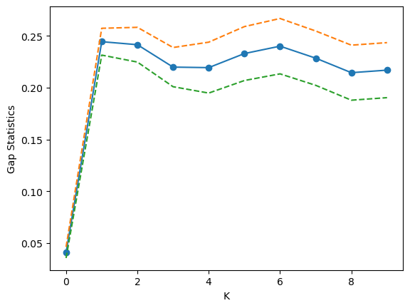

```python
lss0m = lss0.mean(axis=0)
lss0sd = lss0.std(axis=0, ddof=1) * np.sqrt(1 + 1 / B)
diff = lss0m - lss
plt.plot(diff, marker='o')
plt.plot(diff + lss0sd, linestyle='--')
plt.plot(diff - lss0sd, linestyle='--')
plt.xlabel("K")
plt.ylabel("Gap Statistics")
plt.show()
```

### Silhouette Plots

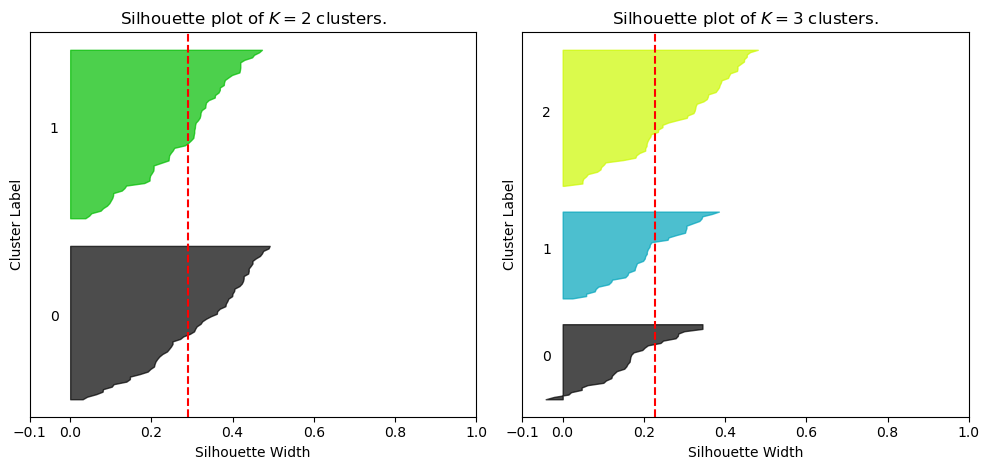

```python
fig, axes = plt.subplots(nrows=1, ncols=2)
silhouette_plot(km2, sportsranks, axes[0])
silhouette_plot(km3, sportsranks, axes[1])
fig.set_figwidth(10)
fig.tight_layout()
```

Compute and plot average silhouette over a range of K values.

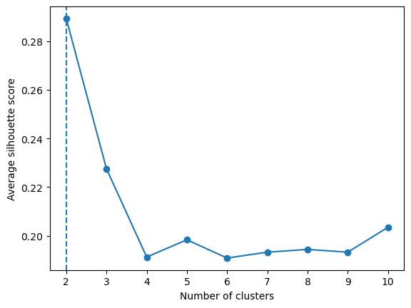

```python
k_max = 10
sil = []

for i in range(2, k_max + 1):
    km_temp = KMeans(n_clusters=i, n_init=10).fit(sportsranks)
    sil_avg = silhouette_score(sportsranks, km_temp.labels_)
    sil.append(sil_avg)

plt.plot(range(2, k_max + 1), sil, marker='o')
plt.xlabel('Number of clusters')
plt.ylabel('Average silhouette score')
plt.axvline(x=sil.index(max(sil)) + 2, linestyle="--")
```

## PAM (Partitioning Around Medoids)

```python
pam2 = KMedoids(n_clusters=2, method='pam').fit(sportsranks)
pam3 = KMedoids(n_clusters=3, method='pam').fit(sportsranks)
```

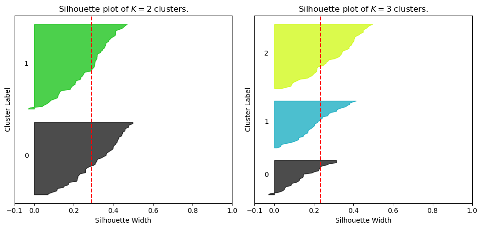

```python
fig, axes = plt.subplots(nrows=1, ncols=2)
silhouette_plot(pam2, sportsranks, axes[0])
silhouette_plot(pam3, sportsranks, axes[1])
fig.set_figwidth(10)
fig.tight_layout()
```

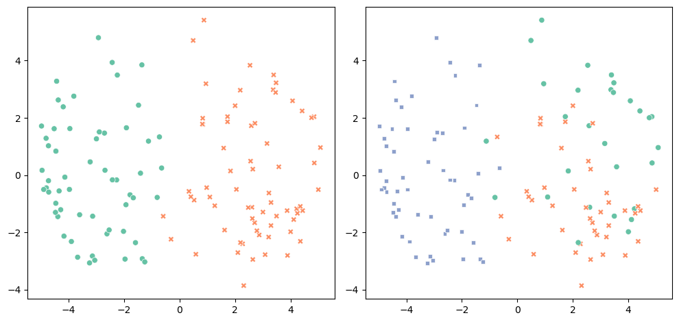

```python
D = pairwise_distances(sportsranks)
Xmds = cmdscale(D)

fig, axes = plt.subplots(nrows=1, ncols=2)
sns.scatterplot(x=Xmds[:, 0], y=Xmds[:, 1], hue=pam2.labels_,
                style=pam2.labels_, palette="Set2", legend=False, ax=axes[0])
sns.scatterplot(x=Xmds[:, 0], y=Xmds[:, 1], hue=pam3.labels_,
                style=pam3.labels_, palette="Set2", legend=False, ax=axes[1])
fig.set_figwidth(10)
fig.tight_layout()
```

Compare PAM with K-means using confusion matrices.

```python
confusion_matrix(km2.labels_, pam2.labels_)
```

```
array([[60,  2],
       [ 0, 68]], dtype=int64)
```

```python
confusion_matrix(km3.labels_, pam3.labels_)
```

```
array([[29,  4,  0],
       [ 0, 38,  0],
       [ 2,  0, 57]], dtype=int64)
```

## Hierarchical Clustering

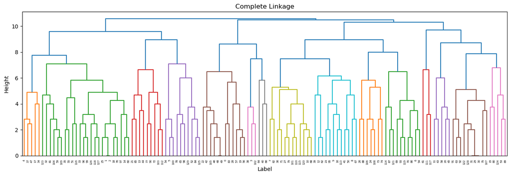

```python
dm = D[np.triu_indices(n, k=1)]
Z = linkage(dm, method='complete')

fig, ax = plt.subplots()
d = dendrogram(Z, orientation='top', ax=ax)
ax.set_title('Complete Linkage')
ax.set_xlabel('Label')
ax.set_ylabel('Height')
fig.set_figwidth(16)
```

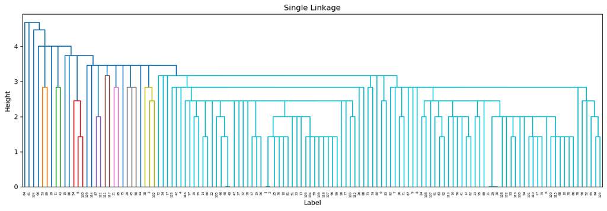

```python
Z = linkage(dm, method='single')

fig, ax = plt.subplots()
d = dendrogram(Z, orientation='top', ax=ax)
ax.set_title('Single Linkage')
ax.set_xlabel('Label')
ax.set_ylabel('Height')
fig.set_figwidth(16)
```

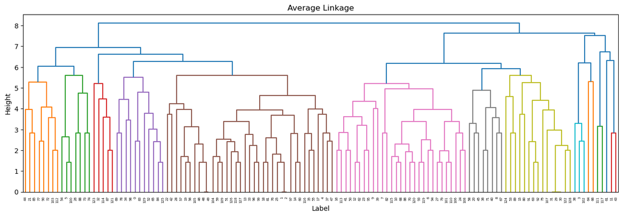

```python
Z = linkage(dm, method='average')

fig, ax = plt.subplots()
d = dendrogram(Z, orientation='top', ax=ax)
ax.set_title('Average Linkage')
ax.set_xlabel('Label')
ax.set_ylabel('Height')
fig.set_figwidth(16)
```

## Vector Quantization

Let's demonstrate an interesting application of k-means: image compression. Take, for instance, this image of my son alongside his cherished toy, Curious George.

[figure not shown]

```python
X = pd.read_table("../image.txt", sep="\s+", header=None)
X = X.to_numpy()
plt.imshow(X, cmap='gray')
plt.show()
```

To compress this image, we segment it into small 6x6 patches. For each patch, we extract its grayscale values, representing them as a 36x1 vector. Consequently, our data matrix, which I refer to as `Z`, has dimensions 2700x36. This means the original image has been divided into nearly 3,000 individual patches.

```python
p = 36
Z = np.empty((0, 36))
n = (270 * 360) // 36
for i in range(360 // 6):
    for j in range(270 // 6):
        k = 6 * i
        l = 6 * j
        tmpX = X[l:(l + 6), k:(k + 6)].flatten()
        Z = np.vstack((Z, tmpX))
Z.shape
```

```
(2700, 36)
```

Every row in matrix `Z` represents a patch, depicted as a vector in this 36-dimensional space. We'll then apply K-means to matrix Z, setting k=40. Consequently, we'll identify 40 distinct cluster centers. Each of these centers is represented by a 36x1 vector, which can also be visualized as a 6x6 patch.

With these centers in hand, we'll reconstruct the image, replacing the original 6x6 patches with their nearest cluster centers. The end result is an image reconstructed using only **40** unique patches. Naturally, this compressed image isn't as detailed as the original, which utilized **2,700** distinct patches, but it significantly reduces the file size. Despite this compression, the main features remain discernible: we can still identify both my son's face and Curious George. And impressively, the entire compression process hinges on the simple K-means algorithm.

```python
mykm = KMeans(n_clusters=40, n_init=10).fit(Z)
mykm_pred = mykm.cluster_centers_[mykm.predict(Z)]
```

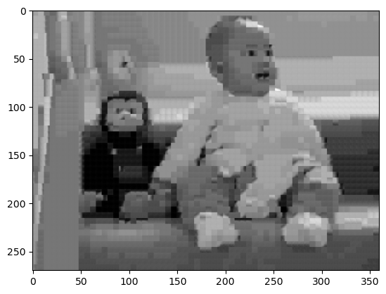

```python
newX = np.zeros((270, 360))

m = 0
for i in range(360 // 6):
    for j in range(270 // 6):
        k = 6 * i
        l = 6 * j
        newX[l:(l + 6), k:(k + 6)] = mykm_pred[m].reshape(6, 6)
        m += 1

plt.imshow(newX, cmap='gray')
```